# Mind Map: Semi-Supervised Topic Extraction

2020-06-15

## Motivation

- No best practices for *classifying* topics within corpora
- Our goal: extract one or more predefined topics of interest
- Improve upon dictionary methods while preserving their efficiency

## Dictionary approaches

- Use an off-the-shelf lists of words that signify a concept of interest
- Domain-sensitive and have may low reliability ([Barbera et al 2020](https://www.cambridge.org/core/journals/political-analysis/article/automated-text-classification-of-news-articles-a-practical-guide/10462DB284B1CD80C0FAE796AD786BC6), [Frimer 2019](http://www.jeremyfrimer.com/uploads/2/1/2/7/21278832/frimer__2019__jrp_.pdf))
- Efficient but don’t use any information from the corpus being analyzed

## Traditional Topic Modeling

- Method of dimensionality reduction: assumes that words are more likely to occur in certain topics relative to others
- Cannot select topic of interest at the outset
- Cannot predefine the level of generality (e.g. general topics versus subtopics).
- Involves lots of manual ‘tuning,’ raising questions about researcher discretion and reproducibility

## An Alternative

- Draw upon elements of dictionary methods and topic models via semi-supervised classification
- First used in [Bakshy, Messing, Adamic 2015](https://science.sciencemag.org/content/348/6239/1130.abstract)

## The ‘Mind Map’

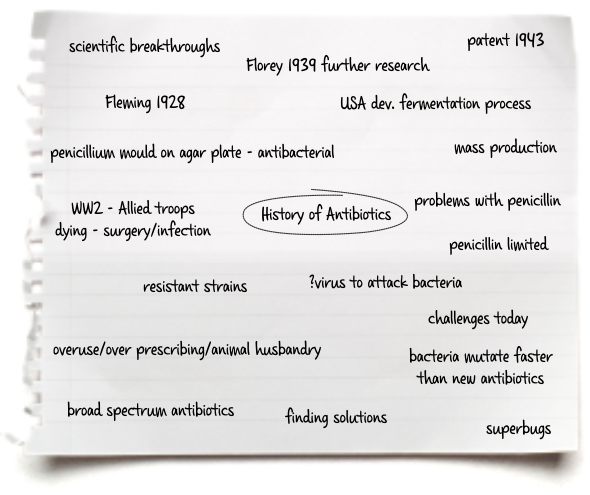

## Algorithm

1. A set of ‘seed’ words that we know are about the topic.
2. Apply positive label to any documents containing those words
3. Estimate a machine classification model to identify other words that co-occur with positive examples
4. Extrapolate the model to the entire dataset

## Validation

1. Remove one of the seed words from the seed set
2. Assign positive labels only to documents containing that word
3. Evaluate how well a model can recover the removed word with the remaining seed set
4. Rinse and repeat until all words are evaluated.

## Example 1: Isolating Political News

- How to accurately classify political news without human coders?
- How to validate the accuracy of the classifier without ground truth?

## Political words: Validation

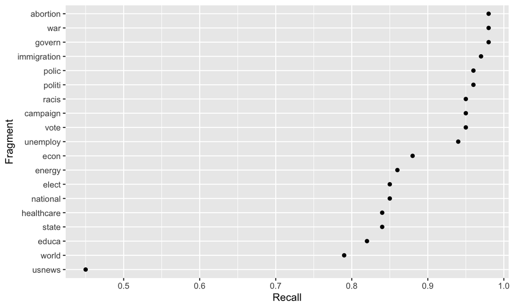

## Results: Political shares by type of link

**About 20%** of random URLs are about politics

## Results: Political misinfo over time

**Over time patterns of political misinfo tend to match trends of politics**

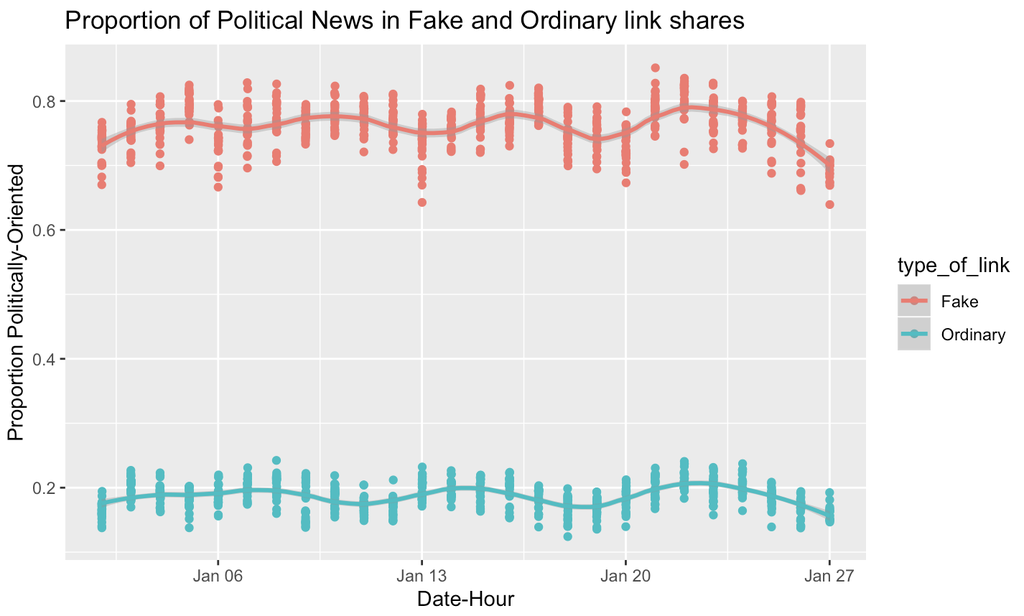

## Example 2: Classifying News into Subtopics

- Focus on sub-types of news content: economy, entertainment, immigration, sports
- Supplement image analysis of who appears in different types of news photos

## Results of Main Analysis by Subtopics

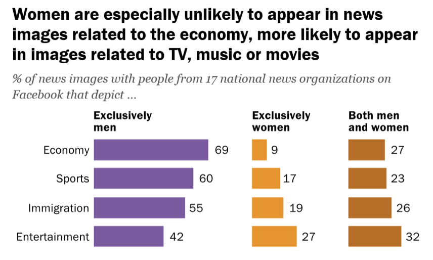

## Validation of Subtopic Classification

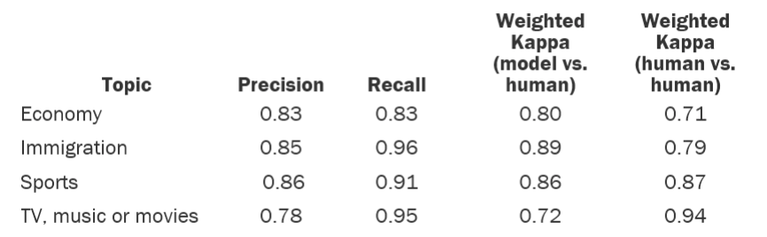